# Chapter 03: Time series decomposition

maurogm 2022-12-11

- Link
- Transformation and adjustments
- Time series components
- Clasical decomposition
- Métodos usados por agencias oficiales
  - X-11
  - SEATS
- STL decomposition

## Link

https://otexts.com/fpp3/decomposition.html

## Transformation and adjustments

Primero habla de cosas medio básicas como normalizar tomando métricas per cápita o ajustar por inflación.

Después explica la Box-Cox transformation, que sirve para reducir la variabilidad de la serie, e idealmente hacer que los efectos estacionales sean parecidos a lo largo de toda la serie.

Por ejemplo, acá se tiene la producción de gas histórica de Australia:

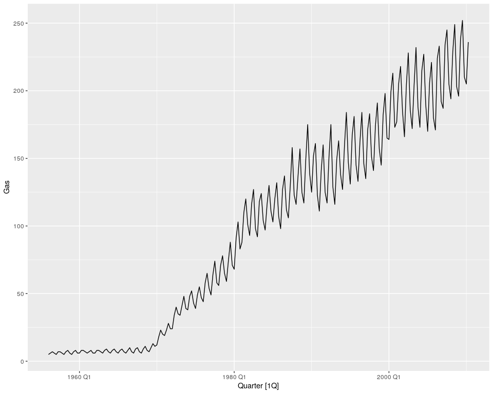

```r
aus_production %>%
  autoplot(Gas)
```

Y acá está después de aplicarle la transformación de Box-Cox para un lambda que elije automáticamente usando la función `features`:

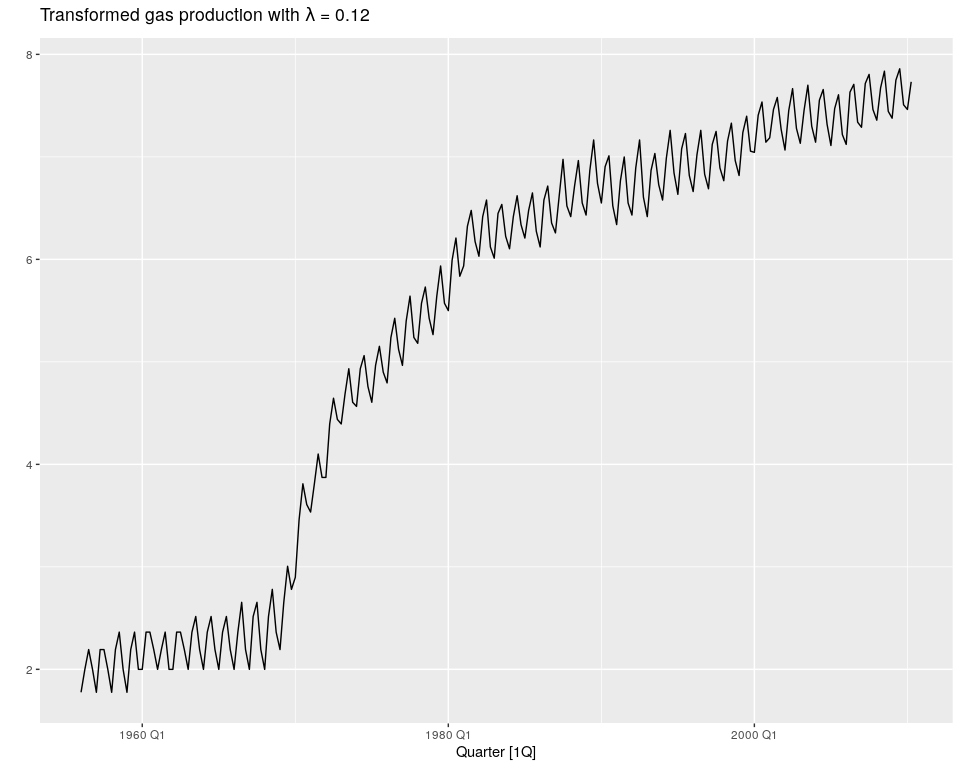

```r
lambda <- aus_production %>%
  features(Gas, features = guerrero) %>%
  pull(lambda_guerrero)
aus_production %>%
  autoplot(box_cox(Gas, lambda)) +
  labs(
    y = "",
    title = latex2exp::TeX(paste0(
      "Transformed gas production with $\\lambda$ = ",
      round(lambda, 2)
    ))
  )
```

## Time series components

Más adelante se verá con mayor detalle, pero acá muestra una forma de descomponer una serie en componentes (estacional + trend-cycle + reminder):

```r
us_retail_employment <- us_employment %>%
  filter(year(Month) >= 1990, Title == "Retail Trade") %>%
  select(-Series_ID)
dcmp <- us_retail_employment %>%
  model(stl = STL(Employed))
components(dcmp) %>% head()
```

```
## # A dable: 6 x 7 [1M]
## # Key:     .model [1]
## # :        Employed = trend + season_year + remainder
##   .model    Month Employed  trend season_year remainder season_adjust
##   <chr>     <mth>    <dbl>  <dbl>       <dbl>     <dbl>         <dbl>
## 1 stl    1990 Jan   13256. 13288.       -33.0     0.836        13289.
## 2 stl    1990 Feb   12966. 13269.      -258.    -44.6          13224.
## 3 stl    1990 Mar   12938. 13250.      -290.    -22.1          13228.
## 4 stl    1990 Apr   13012. 13231.      -220.      1.05         13232.
## 5 stl    1990 May   13108. 13211.      -114.     11.3          13223.
## 6 stl    1990 Jun   13183. 13192.       -24.3    15.5          13207.
```

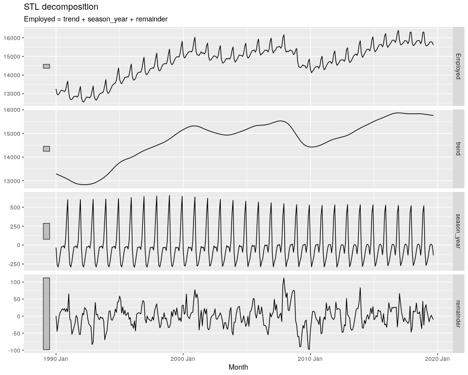

```r
components(dcmp) %>% autoplot()
```

Está bueno que `components` ya incluye una columna con la serie desestacionalizada, lista para usar:

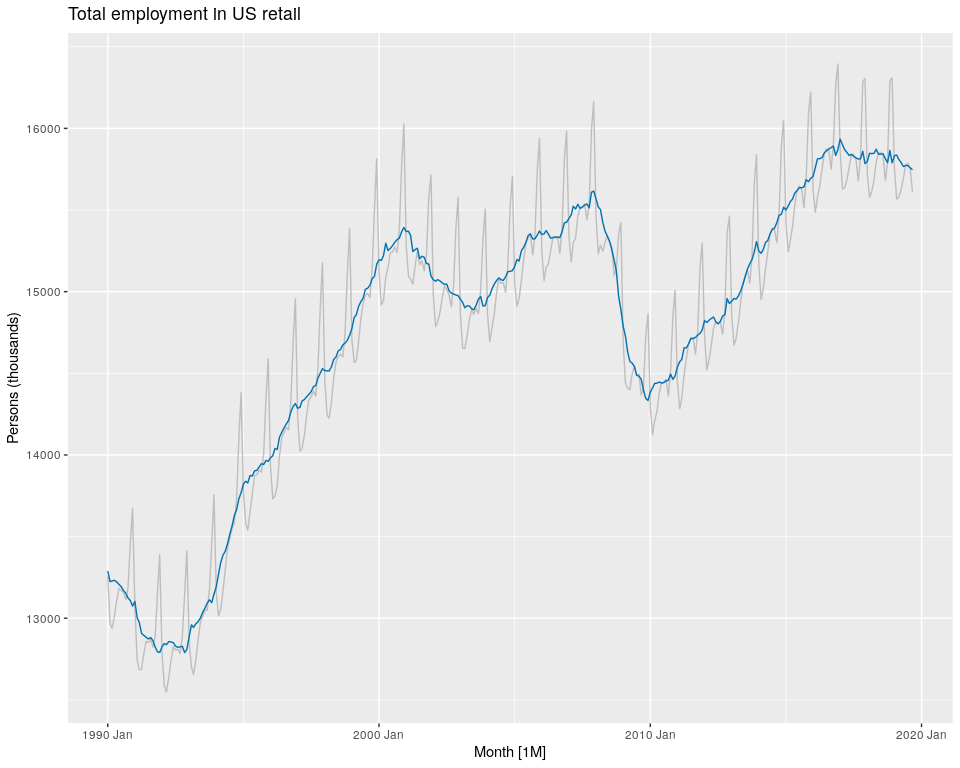

```r
components(dcmp) %>%
  as_tsibble() %>%
  autoplot(Employed, colour = "gray") +
  geom_line(aes(y = season_adjust), colour = "#0072B2") +
  labs(
    y = "Persons (thousands)",
    title = "Total employment in US retail"
  )
```

## Clasical decomposition

Cuenta un algoritmo rudimentario (data de los 1920s) para descomponer una serie (ya sea en suma o en producto de componentes).

La idea es que primero se estima el componente de trend-cycle con promedios móviles, se quita ese componente de la serie original, y del resto se estima el componente estacional como el promedio de cada elemento del período (o sea, el promedio de todos los datos de “viernes” por un lado, de “jueves” por otro, etc.). Lo que sobre es el Reminder.

Este método quedó viejo, y da unas cuantas razones al final.

- No se adapta a cambios abruptos de tendencia.
- No se adapta a cambios en el componente estacional (ej: antes el máximo consumo eléctrico era en invierno para calefaccionar, tras la popularización del aire acondicionado pasó a ser en verano).
- No permite aislar datos atípicos.

## Métodos usados por agencias oficiales

### X-11

Esta descomposición se parece a la anterior, enmienda varias de sus falencias. Por ejemplo, infiere la tendencia también para los extremos de la serie, y permite lentos cambios en el componente estacional.

El siguiente código usa la implementación `X_13ARIMA_SEATS`:

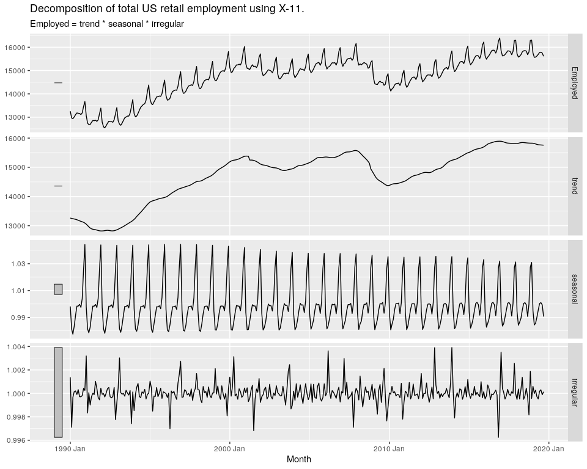

```r
x11_dcmp <- us_retail_employment %>%
  model(x11 = X_13ARIMA_SEATS(Employed ~ x11())) %>%
  components()
autoplot(x11_dcmp) +
  labs(
    title =
      "Decomposition of total US retail employment using X-11."
  )
```

### SEATS

Significa *Seasonal Extraction in ARIMA Time Series*. No entra en detalles técnicos, aunque da un link a bibliografía adecuada.

Para este caso, el resultado es similar al de X-11:

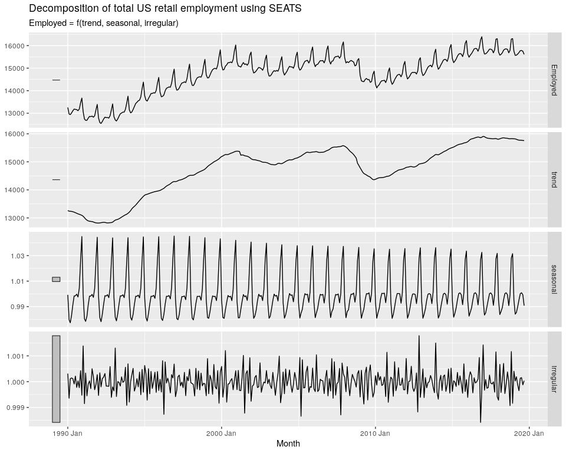

```r
seats_dcmp <- us_retail_employment %>%
  model(seats = X_13ARIMA_SEATS(Employed ~ seats())) %>%
  components()
autoplot(seats_dcmp) +
  labs(
    title =
      "Decomposition of total US retail employment using SEATS"
  )
```

## STL decomposition

Tiene ventajas sobre los métodos anteriores:

- Unlike SEATS and X-11, STL will handle any type of seasonality, not only monthly and quarterly data.
- The seasonal component is allowed to change over time, and the rate of change can be controlled by the user.
- The smoothness of the trend-cycle can also be controlled by the user.
- It can be robust to outliers (i.e., the user can specify a robust decomposition), so that occasional unusual observations will not affect the estimates of the trend-cycle and seasonal components. They will, however, affect the remainder component.

Como desventajas, menciona que *it does not handle trading day or calendar variation automatically*. También que sólo acepta descomposiciones aditivas, pero se puede lograr descomposiciones aditivas tomando el logaritmo de la serie. De quererse algo intermedio, se puede usar una transformación de Box-Cox.

Ejemplo:

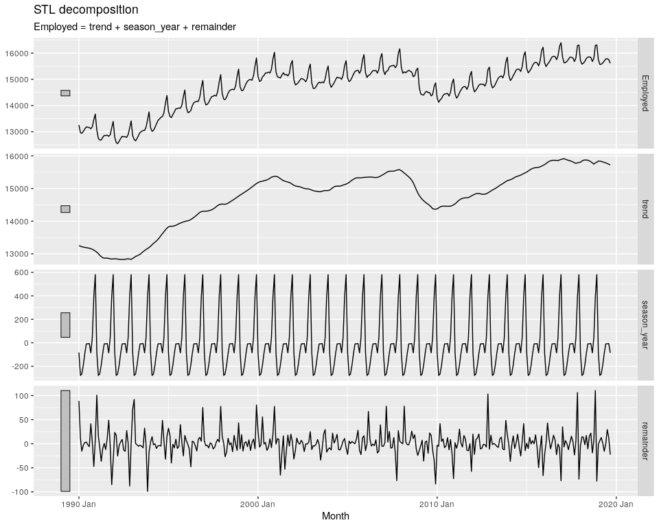

```r
us_retail_employment %>%
  model(
    STL(Employed ~ trend(window = 7) +
      season(window = "periodic"),
    robust = TRUE
    )
  ) %>%
  components() %>%
  autoplot()
```

Para entender mejor cómo usarlo, hay que meterse a jugar con el código y la documentación.